**We would like to acknowledge University of Michigan's EECS 498-007/598-005 on which we based the development of this project.**

# Variational Autoencoder

In this notebook, you will implement a variational autoencoder (VAE) and a conditional variational autoencoder (CVAE) and apply them to the MNIST handwritten digit dataset. An autoencoder learns a compact latent representation of training images and reconstructs them from that representation. The VAE extends this by making the encoder and decoder probabilistic, allowing us to sample from the learned latent distribution to generate new images.

## Assignment Overview

All your code goes in `vae.py`. The notebook imports from it and runs checks — do not modify the notebook cells.

| Task | Points |
| --- | --- |
| `VAE.__init__` — encoder, `mu_layer`, `logvar_layer` | 4 |
| `VAE.__init__` — decoder | 1 |
| `VAE.forward` | 1 |
| `reparametrize` | 2 |
| `loss_function` | 1 |
| `CVAE.__init__` + `CVAE.forward` | 3 |
| **Total** | **12** |

`train_vae`, `show_images`, `reset_seed`, `rel_error`, and `one_hot` are all provided in `vae_utils.py` — do not modify that file.

```python
import os
import sys
sys.path.insert(0, os.path.dirname(os.path.abspath('vae.py')))
print('cwd:', os.getcwd())
```

```
cwd: /content
```

```python
import importlib
import sys
sys.modules["imp"] = importlib

%load_ext autoreload
%autoreload 2

import torch
import torch.nn as nn
import torch.nn.functional as F
import torch.optim as optim
import torchvision.transforms as T
import torchvision.datasets as dset
from torch.utils.data import DataLoader
import matplotlib.pyplot as plt
import matplotlib.gridspec as gridspec

from vae_utils import rel_error, reset_seed, show_images, train_vae, count_params

%matplotlib inline
plt.rcParams['figure.figsize'] = (10.0, 8.0)
plt.rcParams['font.size'] = 16
plt.rcParams['image.interpolation'] = 'nearest'
plt.rcParams['image.cmap'] = 'gray'

device = (
    torch.device('cuda') if torch.cuda.is_available()
    else torch.device('mps') if torch.backends.mps.is_available()
    else torch.device('cpu')
)
print('Using device:', device)
```

```
Using device: cuda
```

## Load MNIST Dataset

```python
batch_size = 128

mnist_train = dset.MNIST('./mnist_data', train=True, download=True, transform=T.ToTensor())
loader_train = DataLoader(mnist_train, batch_size=batch_size, shuffle=True, drop_last=True, num_workers=0)
```

## Visualize Dataset

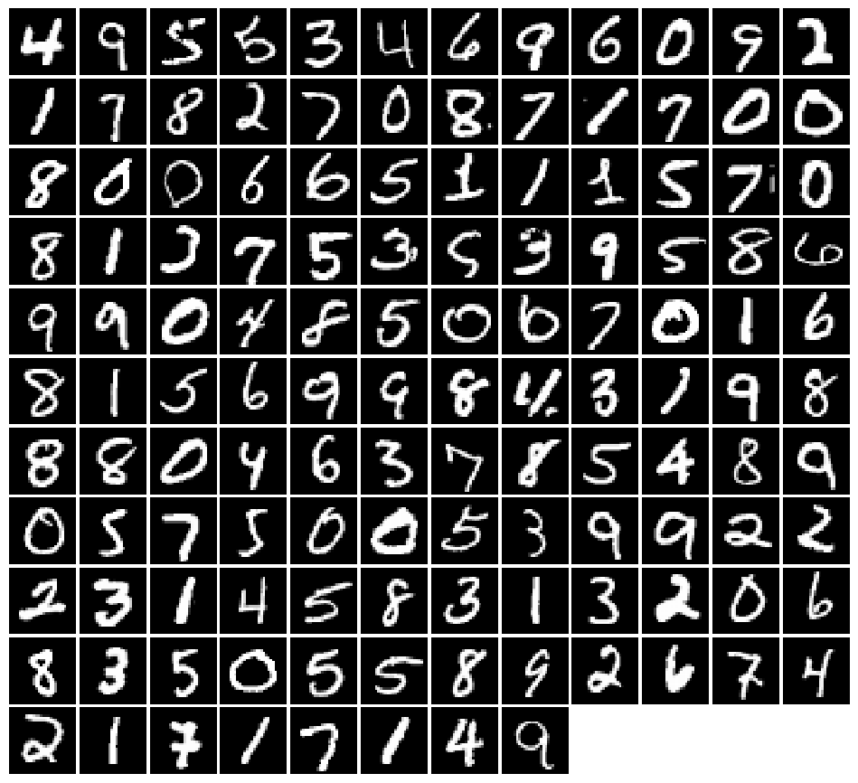

```python
imgs = next(iter(loader_train))[0]
show_images(imgs)
```

# Fully Connected VAE

Our first VAE implementation will consist solely of fully connected layers. We'll take the `1 x 28 x 28` shape of our input and flatten the features to create an input dimension size of 784. In this section you'll define the encoder and decoder in the `VAE` class in `vae.py`, implement the reparametrization trick, the forward pass, and the loss function.

## FC-VAE Encoder (4 points)

Build the encoder inside `VAE.__init__` in `vae.py`. Set `self.hidden_dim = 400` and define:

- `self.encoder` — an `nn.Sequential` that maps `(N, 1, H, W)` → `(N, hidden_dim)`
- `self.mu_layer` — a single `nn.Linear` that maps `(N, hidden_dim)` → `(N, Z)`
- `self.logvar_layer` — a single `nn.Linear` that maps `(N, hidden_dim)` → `(N, Z)`

Encoder architecture:

- `nn.Flatten()`
- Linear(`input_size` → `hidden_dim`) + ReLU
- Linear(`hidden_dim` → `hidden_dim`) + ReLU
- Linear(`hidden_dim` → `hidden_dim`) + ReLU

```python
from vae import VAE

def test_encoder(model, input_size, hidden_dim, n_encoder_lin_layers):
    expected = (input_size + 1) * hidden_dim + (n_encoder_lin_layers - 1) * (hidden_dim + 1) * hidden_dim
    actual = count_params(model.encoder)
    if actual == expected:
        print('Correct number of parameters in model.encoder.')
    else:
        print('Incorrect number of parameters in model.encoder. (mu_layer and logvar_layer should be separate)')

def test_mu_logvar(model, hidden_dim, latent_size):
    for name, layer in [('mu_layer', model.mu_layer), ('logvar_layer', model.logvar_layer)]:
        expected = (hidden_dim + 1) * latent_size
        actual = count_params(layer)
        status = 'Correct' if actual == expected else 'Incorrect'
        print(f'{status} number of parameters in model.{name}.')

test_encoder(VAE(345, 17), 345, 400, 3)
test_mu_logvar(VAE(345, 17), 400, 17)
```

```
Correct number of parameters in model.encoder.
Correct number of parameters in model.mu_layer.
Correct number of parameters in model.logvar_layer.
```

## FC-VAE Decoder (1 point)

Build the decoder inside `VAE.__init__`. Define `self.decoder` as an `nn.Sequential` that maps `(N, Z)` → `(N, 1, H, W)`.

Decoder architecture:

- Linear(`latent_size` → `hidden_dim`) + ReLU
- Linear(`hidden_dim` → `hidden_dim`) + ReLU
- Linear(`hidden_dim` → `hidden_dim`) + ReLU
- Linear(`hidden_dim` → `input_size`) + Sigmoid
- `nn.Unflatten(1, (1, 28, 28))`

```python
from vae import VAE

def test_decoder(model, input_size, hidden_dim, latent_size, n_decoder_lin_layers):
    expected = (
        (latent_size + 1) * hidden_dim
        + (n_decoder_lin_layers - 2) * (hidden_dim + 1) * hidden_dim
        + (hidden_dim + 1) * input_size
    )
    actual = count_params(model.decoder)
    status = 'Correct' if actual == expected else 'Incorrect'
    print(f'{status} number of parameters in model.decoder.')

test_decoder(VAE(345, 17), 345, 400, 17, 4)
```

```
Correct number of parameters in model.decoder.
```

## Reparametrization (2 points)

To sample a latent vector $z$ from $q_\phi(z|x) = \mathcal{N}(\mu, \sigma^2)$ in a differentiable way, we use the reparametrization trick:

$$z = \mu + \sigma \cdot \epsilon, \quad \epsilon \sim \mathcal{N}(0, 1)$$

This lets gradients flow back through $z$ to $\mu$ and $\sigma$ during backpropagation.

Implement `reparametrize` in `vae.py`. Verify that your mean and std errors are below `1e-4`.

```python
reset_seed(0)
from vae import reparametrize

latent_size = 15
size = (1, latent_size)
mu = torch.zeros(size)
logvar = torch.ones(size)

z = reparametrize(mu, logvar)

expected_mean = torch.FloatTensor([-0.4363])
expected_std = torch.FloatTensor([1.6860])
assert z.size() == size
print('Mean Error', rel_error(torch.mean(z, dim=-1), expected_mean))
print('Std Error',  rel_error(torch.std(z, dim=-1),  expected_std))
```

```
Mean Error 5.639056398351415e-05
Std Error 7.1412955526273885e-06
```

## FC-VAE Forward (1 point)

Implement `VAE.forward` in `vae.py`. Pass the input through the encoder to get `mu` and `logvar`, reparametrize to get `z`, then decode `z` to reconstruct the image.

```python
from vae import VAE

def test_VAE_shapes():
    all_correct = True
    with torch.no_grad():
        batch_size = 3
        latent_size = 17
        x_hat, mu, logvar = VAE(28 * 28, latent_size)(torch.ones(batch_size, 1, 28, 28))
        for name, tensor, expected in [
            ('x_hat',  x_hat,  (batch_size, 1, 28, 28)),
            ('mu',     mu,     (batch_size, latent_size)),
            ('logvar', logvar, (batch_size, latent_size)),
        ]:
            if tuple(tensor.shape) != expected:
                print(f'{name}: expected {expected}, got {tuple(tensor.shape)}')
                all_correct = False
        if all_correct:
            print('Shapes of x_hat, mu, and logvar are correct.')
        if batch_size > 1 and x_hat.std(0).mean() == 0:
            print('Warning: x_hat has no randomness — check reparametrize.')

test_VAE_shapes()
```

```
Shapes of x_hat, mu, and logvar are correct.
```

## Loss Function (1 point)

The VAE loss is the negative variational lower bound:

$$\mathcal{L} = \underbrace{-\mathbb{E}_{z \sim q_\phi}[\log p_\theta(x|z)]}_{\text{reconstruction}} + \underbrace{D_{KL}(q_\phi(z|x) \| p(z))}_{\text{KL divergence}}$$

The KL term has a closed form for diagonal Gaussians vs. a standard normal prior:

$$D_{KL} = -\frac{1}{2} \sum_{j=1}^{Z} \left(1 + \log\sigma^2_j - \mu^2_j - \sigma^2_j\right)$$

Implement `loss_function` in `vae.py`. Use `F.binary_cross_entropy(x_hat, x, reduction='sum')` for the reconstruction term. Average the total loss over the batch. Your relative error should be ≤ `1e-5`.

```python
from vae import loss_function

image_hat = torch.sigmoid(torch.FloatTensor([[2, 5], [6, 7]]).unsqueeze(0).unsqueeze(0))
image     = torch.sigmoid(torch.FloatTensor([[1, 10], [9, 3]]).unsqueeze(0).unsqueeze(0))
image_hat = torch.tile(image_hat, (10, 1, 1, 1))
image     = torch.tile(image, (10, 1, 1, 1))

mu_shape = (image.shape[0], 15)
mu, logvar = torch.ones(mu_shape), torch.zeros(mu_shape)

expected_out = torch.tensor(1.0079 + 7.5000)
out = loss_function(image_hat, image, mu, logvar)
print('Loss error', rel_error(expected_out, out))
```

```
Loss error 2.1297676389877955e-06
```

## Train VAE

`train_vae` is provided in `vae_utils.py`. Training for 10 epochs should take ~2 minutes and your loss should be less than 120.

```python
from vae import VAE

num_epochs = 10
latent_size = 15
input_size = 28 * 28

vae_model = VAE(input_size, latent_size=latent_size).to(device)
optimizer = optim.Adam(vae_model.parameters(), lr=1e-3)

for epoch in range(num_epochs):
    train_vae(epoch, vae_model, loader_train, optimizer)
```

```
Epoch 0: loss = 190.0974
Epoch 1: loss = 143.5985
Epoch 2: loss = 130.7988
Epoch 3: loss = 126.8050
Epoch 4: loss = 124.0375
Epoch 5: loss = 121.0722
Epoch 6: loss = 118.3619
Epoch 7: loss = 116.4784
Epoch 8: loss = 115.0019
Epoch 9: loss = 113.9125
```

## Visualize Results

Sample random latent vectors and decode them to generate new images. You should be able to visually recognize many digits, though some may be blurry.

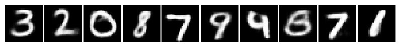

```python
vae_model.eval()
with torch.no_grad():
    z = torch.randn(10, latent_size, device=device)
    samples = vae_model.decoder(z).cpu()

fig = plt.figure(figsize=(10, 1))
gspec = gridspec.GridSpec(1, 10)
gspec.update(wspace=0.05, hspace=0.05)
for i, sample in enumerate(samples):
    ax = plt.subplot(gspec[i])
    plt.axis('off')
    ax.set_aspect('equal')
    plt.imshow(sample.reshape(28, 28), cmap='Greys_r')
```

## Latent Space Interpolation

Generate random latent vectors $z_0$ and $z_1$ and linearly interpolate between them. Each row below interpolates between two random vectors — you should see smooth transitions between digits.

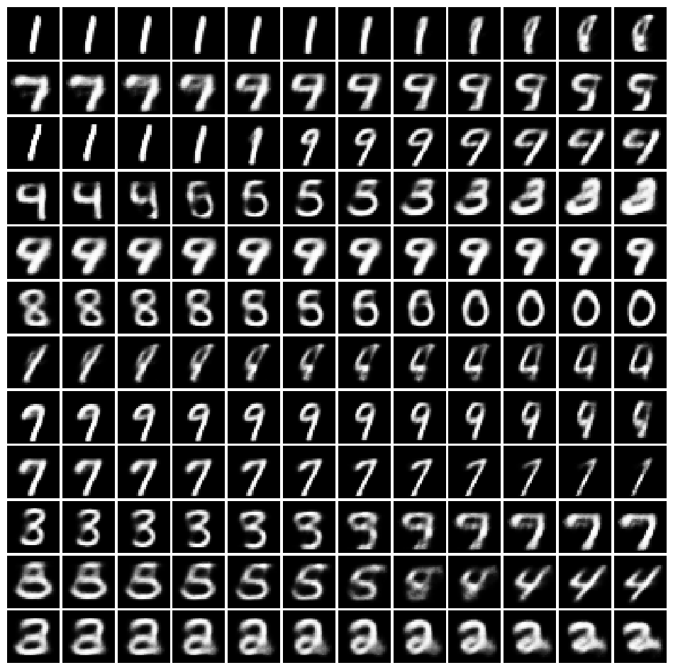

```python
S = 12
vae_model.eval()
with torch.no_grad():
    z0 = torch.randn(S, latent_size, device=device)
    z1 = torch.randn(S, latent_size, device=device)
    w  = torch.linspace(0, 1, S, device=device).view(S, 1, 1)
    z  = (w * z0 + (1 - w) * z1).transpose(0, 1).reshape(S * S, latent_size)
    x  = vae_model.decoder(z).cpu()
show_images(x)
```

# Conditional FC-VAE

The CVAE extends the VAE by conditioning on the class label $c$. Instead of $q_\phi(z|x)$ and $p_\theta(x|z)$ we have $q_\phi(z|x,c)$ and $p_\theta(x|z,c)$. This lets us generate specific digits at inference time by choosing $c$.

## CVAE (3 points)

Implement `CVAE.__init__` and `CVAE.forward` in `vae.py`. Use the same architecture as the VAE with these modifications:

1. **Encoder** input: concatenation of flattened image `(N, H*W)` and one-hot label `(N, K)` → first linear layer takes `H*W + K`. Do **not** put `nn.Flatten` inside the encoder Sequential — flatten in `forward` instead.
2. **Decoder** input: concatenation of latent vector `z` `(N, Z)` and one-hot label `(N, K)` → first linear layer takes `Z + K`.
3. **Forward**: flatten `x`, `torch.cat` with `labels` before encoder; `torch.cat` `z` with `labels` before decoder.

```python
from vae import CVAE

def test_CVAE_shapes():
    all_correct = True
    with torch.no_grad():
        batch_size = 3
        num_classes = 10
        latent_size = 17
        cls = F.one_hot(torch.tensor([3] * batch_size), num_classes=num_classes).float()
        x_hat, mu, logvar = CVAE(28 * 28, num_classes=num_classes, latent_size=latent_size)(
            torch.ones(batch_size, 1, 28, 28), cls
        )
        for name, tensor, expected in [
            ('x_hat',  x_hat,  (batch_size, 1, 28, 28)),
            ('mu',     mu,     (batch_size, latent_size)),
            ('logvar', logvar, (batch_size, latent_size)),
        ]:
            if tuple(tensor.shape) != expected:
                print(f'{name}: expected {expected}, got {tuple(tensor.shape)}')
                all_correct = False
        if all_correct:
            print('Shapes of x_hat, mu, and logvar are correct.')
        if batch_size > 1 and x_hat.std(0).mean() == 0:
            print('Warning: x_hat has no randomness.')

test_CVAE_shapes()
```

```
Shapes of x_hat, mu, and logvar are correct.
```

## Train CVAE

Training for 10 epochs should take ~2 minutes and your loss should be less than 120.

```python
from vae import CVAE

num_epochs = 10
latent_size = 15
input_size = 28 * 28

cvae = CVAE(input_size, latent_size=latent_size).to(device)
optimizer = optim.Adam(cvae.parameters(), lr=1e-3)

for epoch in range(num_epochs):
    train_vae(epoch, cvae, loader_train, optimizer, cond=True)
```

```
Epoch 0: loss = 162.1331
Epoch 1: loss = 119.6202
Epoch 2: loss = 113.1262
Epoch 3: loss = 109.8344
Epoch 4: loss = 107.7104
Epoch 5: loss = 106.2335
Epoch 6: loss = 105.1673
Epoch 7: loss = 104.2920
Epoch 8: loss = 103.5530
Epoch 9: loss = 102.9455
```

## Visualize CVAE Results

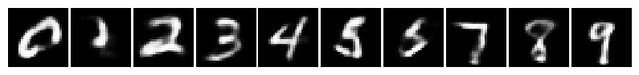

```python
cvae.eval()
with torch.no_grad():
    z = torch.randn(10, latent_size)
    c = torch.eye(10, 10)  # one-hot labels for digits 0-9
    zc = torch.cat((z, c), dim=-1).to(device)
    samples = cvae.decoder(zc).cpu()

fig = plt.figure(figsize=(10, 1))
gspec = gridspec.GridSpec(1, 10)
gspec.update(wspace=0.05, hspace=0.05)
for i, sample in enumerate(samples):
    ax = plt.subplot(gspec[i])
    plt.axis('off')
    ax.set_aspect('equal')
    plt.imshow(sample.reshape(28, 28), cmap='Greys_r')
```